# R Notebook

Due 10/20

The Mayor and his Cabinet have asked the Citywide Analytics Team to look into the City’s 311 data and determine the following:

1. How long does it take to complete a request city-wide (hence known as close time)? Please provide 3 metrics to answer this question.
   - Why did you choose the 3 metrics?
   - What does the 3 metrics say collectively? For example, if one of your metrics is the mean, what might that number miss? What other metrics might you want to pull to supplement what the mean misses.
2. Assume that the primary goal of your analysis is to ensure that all city departments have as short of a close time as possible.
   - What are the 3 departments that the City should focus on? Note the language here. Yes it is vague. It will be up to you to define what “should focus on” is and then conduct your analysis.
   - What are the 3 departments that have done well so far?
3. In words, describe 2 confounding factors that can impact the close time of a ticket. You must be able to calculate these confounding factors from the dataset
4. In words, describe a confounding factor that can impact the close time of a ticket. This factor will come from an outside dataset.
   - Describe how you might be able to find this dataset.
   - Describe exactly how you will join this outside dataset to the 311 ticket data
5. How long does it take to complete a request city-wide (hence known as close time)? Please provide 3 metrics to answer this question.
   - Why did you choose the 3 metrics?
   - What does the 3 metrics say collectively? For example, if one of your metrics is the mean, what might that number miss? What other metrics might you want to pull to supplement what the mean misses.

We could naively believe that a mean would represent the close time well. When we calculate that we get:

| close_time_mean |
| --- |
| 6d 11H 54M 37.3724284372292S |

6 days sounds like a long time. However would that make sense if the data looks as it does below?

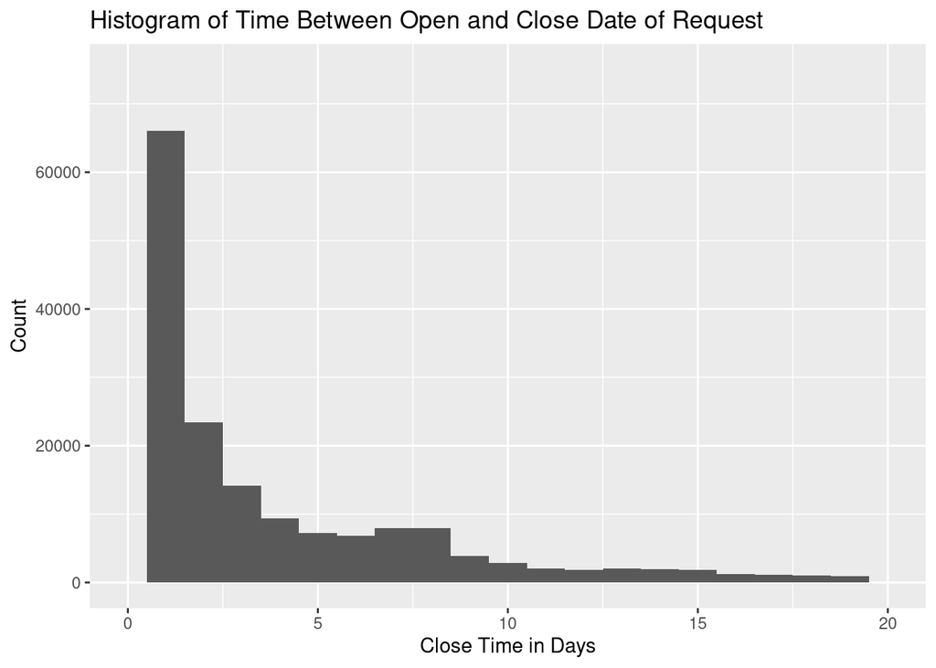

We see that the distribution for the time between when a request is opened and closed is very skewed. So if we were to measure or represent how long it would take to complete a request, we should at least use a statistic that is robust to outliers and skew. If we take a median we get a median close time of about 8.5 hours.

| close_time_median |
| --- |
| 8H 38M 29S |

However, if we break the close time down by the department for which the request is for, we see the distributions aren’t so simple. In fact it appears that for some departments the distribution may be multi-modal, and there appears to be clear differences between departments. This likely reflects the difference in nature of the requests submitted to each department.

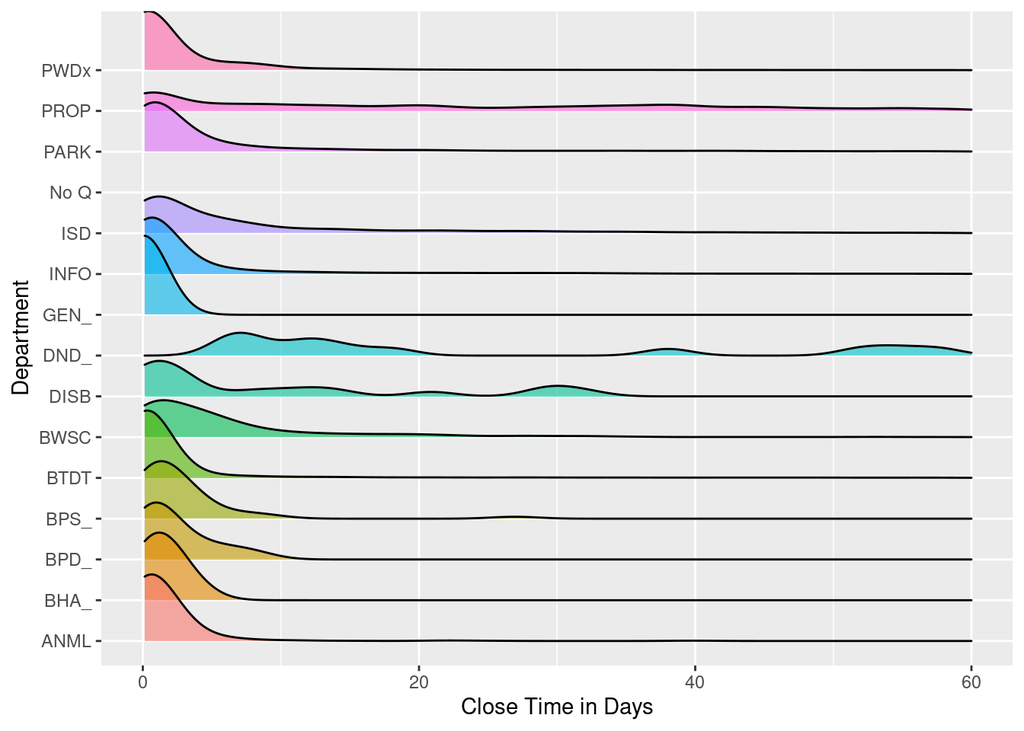

While median is robust to outliers, it may not capture enough information on the width of the distribution. So what if used multiple statistics instead of just one?

[output not shown]

2. Assume that the primary goal of your analysis is to ensure that all city departments have as short of a close time as possible.
   - What are the 3 departments that the City should focus on? Note the language here. Yes it is vague. It will be up to you to define what “should focus on” is and then conduct your analysis.
   - What are the 3 departments that have done well so far?

| department | close_time_median |
| --- | --- |
| PROP | 38d 20H 18M 47S |
| DND_ | 28d 1H 45M 48S |
| ISD | 3d 20H 7M 59S |
| BWSC | 3d 13H 6M 34.5S |
| DISB | 2d 23H 0M 45.5S |
| PARK | 1d 18H 40M 39.5S |
| BPS_ | 1d 10H 45M 54S |
| BPD_ | 1d 0H 12M 58S |
| BHA_ | 23H 56M 48S |
| INFO | 19H 22M 59.5S |

[output cut: 5 more lines]

There are several ways to minimize close time. We could minimize the largest contributors, just based on department median close time, to the overall close time across departments. From the list of median close times shown above it would appear then that the departments that the City should focus on should be Property Management, Inspectional Services, and the Water and Sewer Commission. By the same measure, the best departments are the Transportation Department, Public Works and Animal Control, which I assume is ANML since it’s not defined in the data dictionary. I ignore both DND_ and GEN_ since they are not defined in the data dictionary.

| department | n |
| --- | --- |
| PWDx | 220521 |
| BTDT | 108226 |
| ISD | 25200 |
| PARK | 22572 |
| GEN_ | 20918 |
| INFO | 9042 |
| PROP | 4533 |
| BWSC | 846 |
| ANML | 529 |
| BHA_ | 55 |

[output cut: 5 more lines]

However, given the most requests are for PWDx, BTDT, and ISD, it might make more sense to focus on those departments instead, since they make up the largest proportion of the overall close time.

3. In words, describe 2 confounding factors that can impact the close time of a ticket. You must be able to calculate these confounding factors from the dataset
4. In words, describe a confounding factor that can impact the close time of a ticket. This factor will come from an outside dataset.
   - Describe how you might be able to find this dataset.
   - Describe exactly how you will join this outside dataset to the 311 ticket data